# Diamonds are a Data Scientist’s Best Friend

## Goal

Today we’re going to:

- Introduce plotting with R and the `ggplot2` package
- Provide resources for further reading
- Highlight some best practices

## The Setup

Using `renv` would be the way to go - check out the recording for how to get start with `renv` here. However, `renv` is not the focus of today, plotting in R using the `ggplot2` package is. We’re going to start by attaching the libraries with `library()`. See commented out code for a standard installion of the tidyverse.

```r
# install.packages("pak")
# pak::pak("tidyverse")
```

```r
# suppressing the startup messages
library(tidyverse) |> suppressPackageStartupMessages()

# ggplot2 is a core tidyverse package so it's
# included in the namespace when folks `library(tidyverse)`
```

## The Data

We’ll be working with data that comes along for the ride with the tidyverse packages. You’ll often see these datsets in examples all over the internet. We’ll stick with `diamonds` today.

### Grabbing the Data

```r
# grab the diamonds data like so
data(diamonds)
```

### Data Recon

Lets take a look at this dataset so we can have a better idea of what we are working with.

```r
glimpse(diamonds)
```

```
Rows: 53,940
Columns: 10
$ carat   <dbl> 0.23, 0.21, 0.23, 0.29, 0.31, 0.24, 0.24, 0.26, 0.22, 0.23, 0.…
$ cut     <ord> Ideal, Premium, Good, Premium, Good, Very Good, Very Good, Ver…
$ color   <ord> E, E, E, I, J, J, I, H, E, H, J, J, F, J, E, E, I, J, J, J, I,…
$ clarity <ord> SI2, SI1, VS1, VS2, SI2, VVS2, VVS1, SI1, VS2, VS1, SI1, VS1, …
$ depth   <dbl> 61.5, 59.8, 56.9, 62.4, 63.3, 62.8, 62.3, 61.9, 65.1, 59.4, 64…
$ table   <dbl> 55, 61, 65, 58, 58, 57, 57, 55, 61, 61, 55, 56, 61, 54, 62, 58…
$ price   <int> 326, 326, 327, 334, 335, 336, 336, 337, 337, 338, 339, 340, 34…
$ x       <dbl> 3.95, 3.89, 4.05, 4.20, 4.34, 3.94, 3.95, 4.07, 3.87, 4.00, 4.…
$ y       <dbl> 3.98, 3.84, 4.07, 4.23, 4.35, 3.96, 3.98, 4.11, 3.78, 4.05, 4.…
$ z       <dbl> 2.43, 2.31, 2.31, 2.63, 2.75, 2.48, 2.47, 2.53, 2.49, 2.39, 2.…
```

So we have 10 columns and just under 54,000 rows. Let’s take a high level look at the *content* of the data with `summary()`.

```r
summary(diamonds)
```

```
     carat               cut        color        clarity          depth
 Min.   :0.2000   Fair     : 1610   D: 6775   SI1    :13065   Min.   :43.00
 1st Qu.:0.4000   Good     : 4906   E: 9797   VS2    :12258   1st Qu.:61.00
 Median :0.7000   Very Good:12082   F: 9542   SI2    : 9194   Median :61.80
 Mean   :0.7979   Premium  :13791   G:11292   VS1    : 8171   Mean   :61.75
 3rd Qu.:1.0400   Ideal    :21551   H: 8304   VVS2   : 5066   3rd Qu.:62.50
 Max.   :5.0100                     I: 5422   VVS1   : 3655   Max.   :79.00
                                    J: 2808   (Other): 2531
     table           price             x                y
 Min.   :43.00   Min.   :  326   Min.   : 0.000   Min.   : 0.000
 1st Qu.:56.00   1st Qu.:  950   1st Qu.: 4.710   1st Qu.: 4.720
 Median :57.00   Median : 2401   Median : 5.700   Median : 5.710
 Mean   :57.46   Mean   : 3933   Mean   : 5.731   Mean   : 5.735
 3rd Qu.:59.00   3rd Qu.: 5324   3rd Qu.: 6.540   3rd Qu.: 6.540
 Max.   :95.00   Max.   :18823   Max.   :10.740   Max.   :58.900

       z
 Min.   : 0.000
 1st Qu.: 2.910
 Median : 3.530
 Mean   : 3.539
 3rd Qu.: 4.040
 Max.   :31.800
```

## `ggplot2` and friends

`ggplot2` is now over 10 years old and a stable and trusted package for visualizations. It is based on the core philosphy around Leland Wilkinson’s *The Grammar of Graphics*.

> *Wilkinson, L. (2005), The Grammar of Graphics, 2nd ed., Springer.*

If you like, you can read up on how `ggplot2` incorporates those ideals [ggplot2: Elegant Graphics for Data Analysis (3e)](https://ggplot2-book.org/).

It’s probably safe to say it is a cornerstone of the R community.  
The examples, and [documentation](https://ggplot2.tidyverse.org/) you can find online is often extensive and well written. `python` even has a port of it with the `plotnine` package.

### Syntax Changes: a note about `+`

Right away folks are going to notice that `ggplot2` uses a different syntax than the usual base pipe `|>` or maggritr pipe `%>%` that you will often see out in the wild. This is primarily down to how old the package is, however, I find that `+` more accurately describes the thought process involved with crafting a plot.

With pipes, action happen linearly in order, whereas you an think of `ggplot2` plots like building up a layer cake. You are *adding* layers, quite literally with a `+`.

## ggplot 2 in action

`ggplot2` is fairly flexible in how you structure your commands, so you’re likley to see some variations between developers.

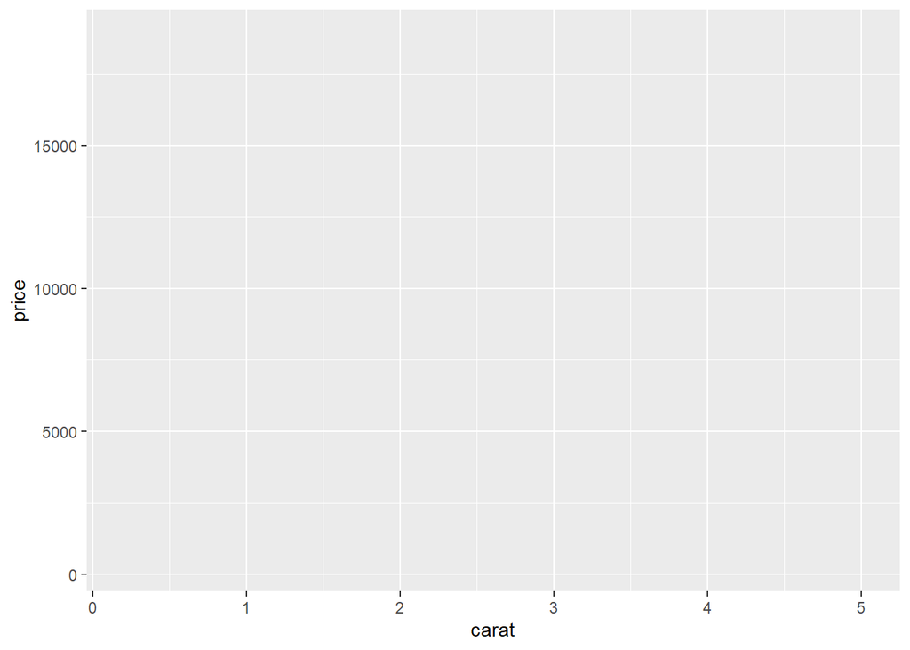

```r
# we can start with the data, or a call to `ggplot()`
# I prefer starting with the data most often, otherwise
# folks can use ggplot(data = diamonds, ...)

# let's start with a look at carat vs price
diamonds |>
    ggplot(
        mapping = aes( # we're mapping our aesthetic, think of it like a base we pin layers to
            x = carat, # x axis
            y = price # y axis
        )
    )
```

If we just run the above, we’ll get a blank plot. However, take a quick look at that - so much of the stage has already been laid out for us. `ggplot2` has fairly sensible defaults, so for the folks who want to get in and get out quickly, they can do that. This allows plotting and visualizations to be used as one part of an exploratory analysis, and not just as a final, finished product, because it is so quick and easy to do once users are acquainted with `ggplot2`.

### Adding points

How about we fill in some useful details, no?

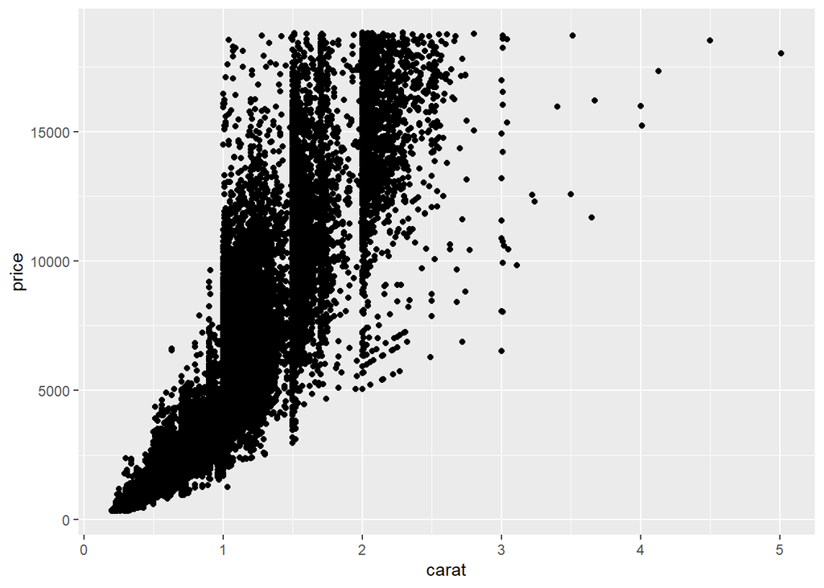

```r
diamonds |>
    ggplot(
        mapping = aes( # we're mapping our aesthetic, think of it like a base we pin layers to
            x = carat, # x axis
            y = price # y axis
        )
# Let's add some layers!
    ) +
# How about some points?
    geom_point()
```

Goodness there is alot going on there! How do we make sense of that mess?

Notice again that we had some fairly sensible defaults, without having to dig into all the arguments of the functions.

First, I want to save some typing. `ggplot2` objects can be saved and combined in fun and exciting ways.

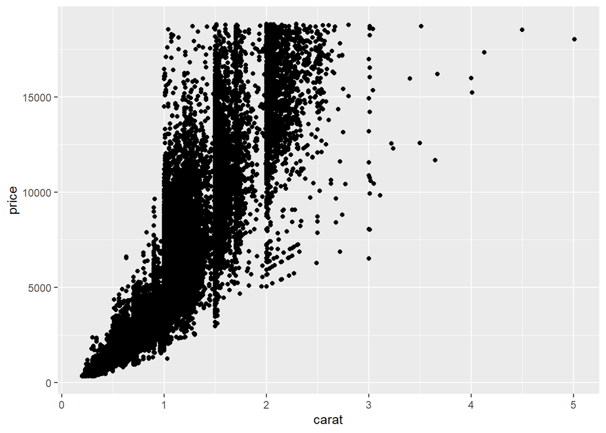

```r
base <-
    diamonds |>
    ggplot(
        mapping = aes( # we're mapping our aesthetic, think of it like a base we pin layers to
            x = carat, # x axis
            y = price # y axis
        )
    )

# the same thing again
base + geom_point()
```

Very cool.

### Adding Color based on Features in the Data

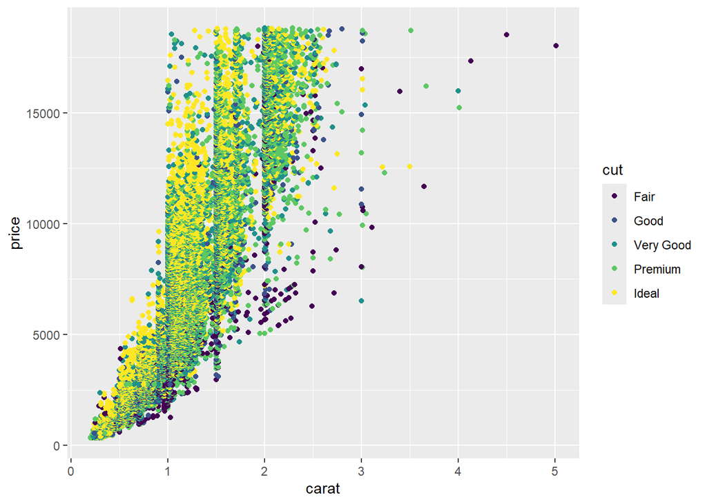

```r
base +
  geom_point(aes(color =  cut))
```

```r
# color is the argument used for points
# which might seem fine here, but most
# geometries that get "filled" with color
# based on the data use the fill argument.
# Try this code cell again with "fill"
# instead of "color" and see what happens.
# Why does that happen?
```

Note that the default color scheme for *ordered* factors with ggplot2 has changed as of a recent update. I think *viridis* is great and is color blind friendly- but if you were expecting something else, well you can always specify otherwise OR just another reason to start adopting a mindset where you are thinking about your dependencies, and perhaps keeping track and controlling them with `renv.

### Cutting through the Noise

Let’s use a boxplot.

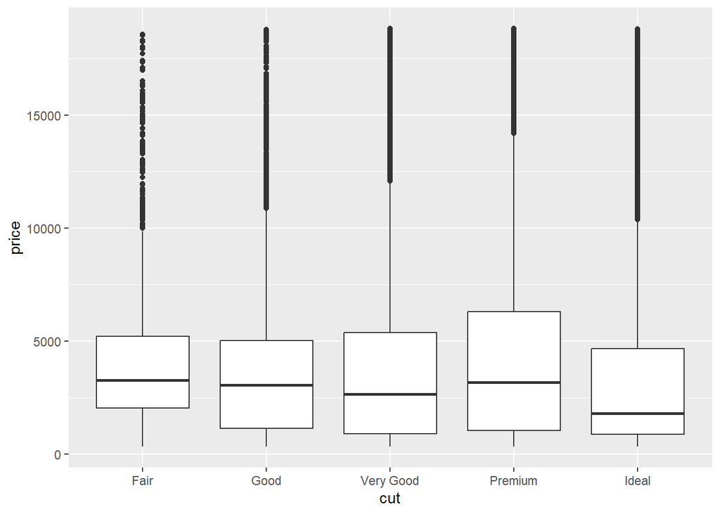

```r
diamonds |>
  ggplot() +
  geom_boxplot(aes(cut, price))
```

How about some trend lines by cut?

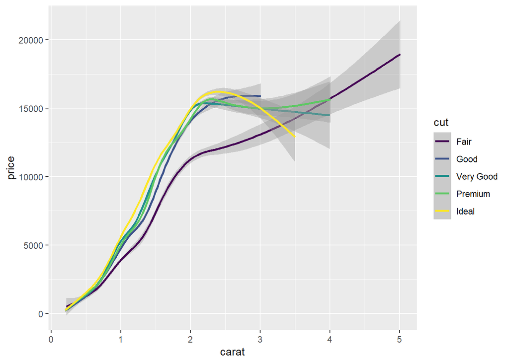

```r
diamonds |>
  ggplot() +
  geom_smooth(aes(carat, price, color = cut))
```

hmmm I want less information…

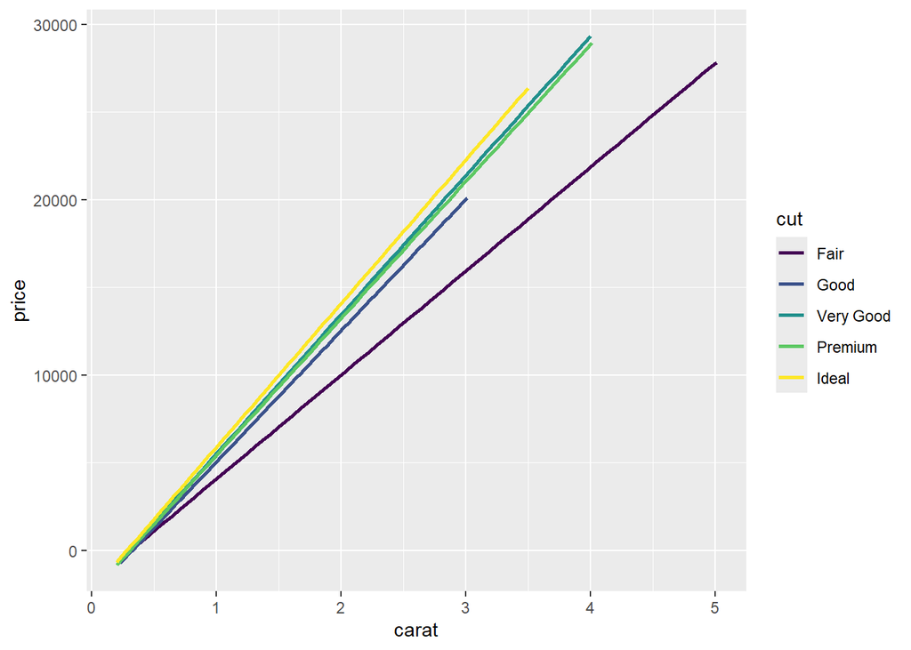

```r
diamonds |>
  ggplot() +
  geom_smooth(
    aes(carat, price, color = cut), # these are the aesthetics based on data
    # below here are arguments we can tweak baseed on the geometry chosen
    method = "lm", # for a linear regression line
    se = FALSE # I don't want to see the confidence interval
  )
```

that’s a bit better. Let’s tidy these up a bit.

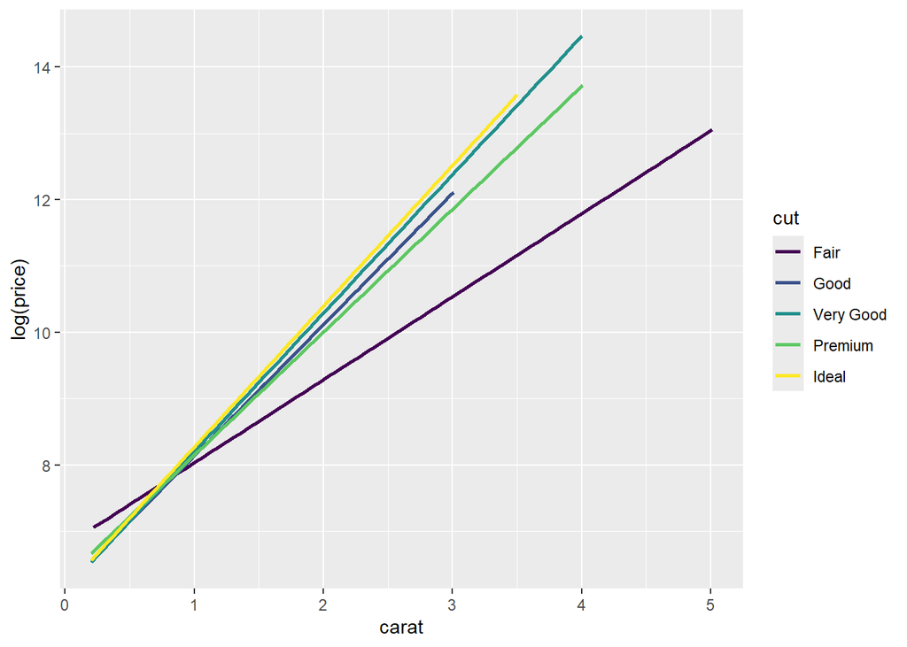

```r
smooth <-
  diamonds |>
  ggplot() +
  geom_smooth(
    aes(
      x = carat,
 # lets use the natural log of price to highlight differences a bit more
      y = log(price),
      color = cut
    ),
    method = "lm",
    se = FALSE
  )

smooth
```

### Tweaking the look and feel

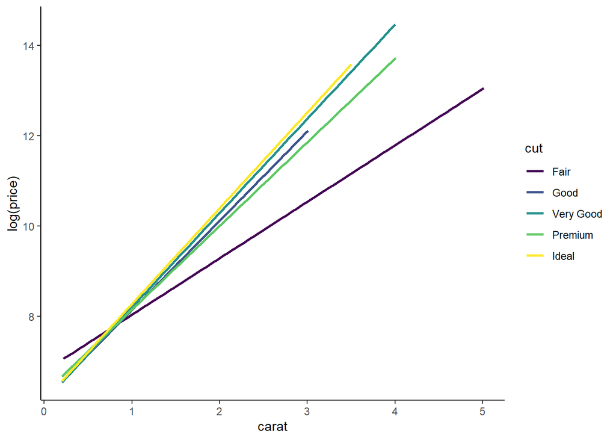

```r
# there are many to choose from - and you can even build your own!

smooth + theme_classic()
```

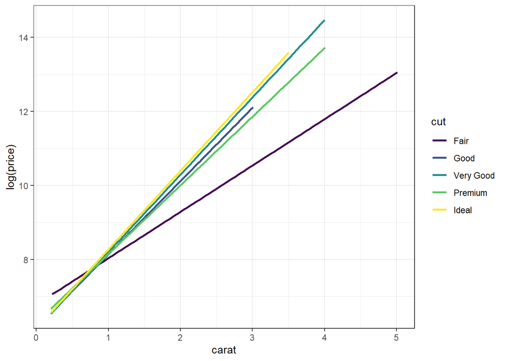

```r
smooth + theme_bw()
```

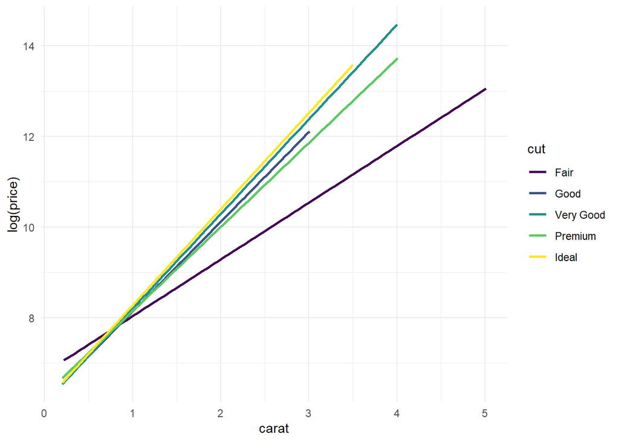

```r
smooth + theme_minimal()
```

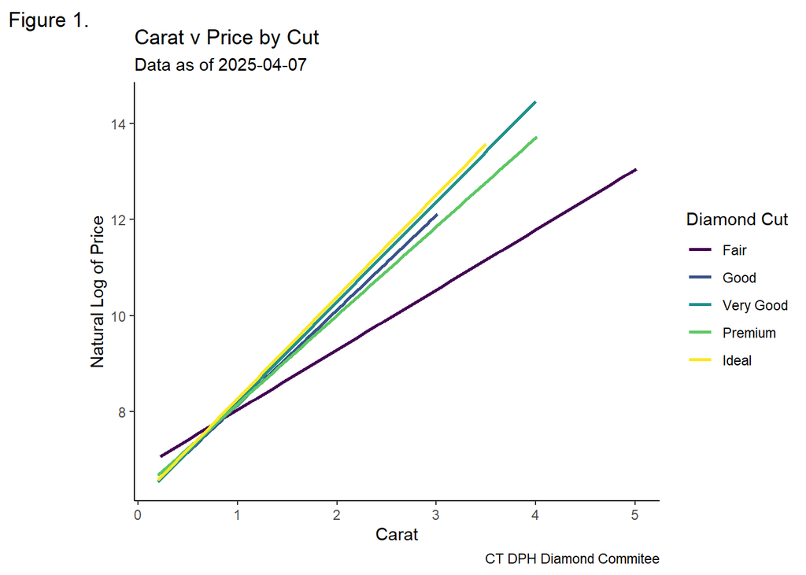

```r
# now for the labels

with_labels <-
  smooth +
  theme_classic() +
  # add some labels
  labs(
    title = "Carat v Price by Cut",
    subtitle = paste("Data as of", lubridate::today()),
    caption = "CT DPH Diamond Commitee",
    tag = "Figure 1.",
    # the next bit refers to the mapped variables x, y etc... BUT it may
    # not always be x and y
    x = "Carat",
    y = "Natural Log of Price",
    col = "Diamond Cut" # can use an empty string "" for no label
  )

with_labels
```

### Misc tweaks

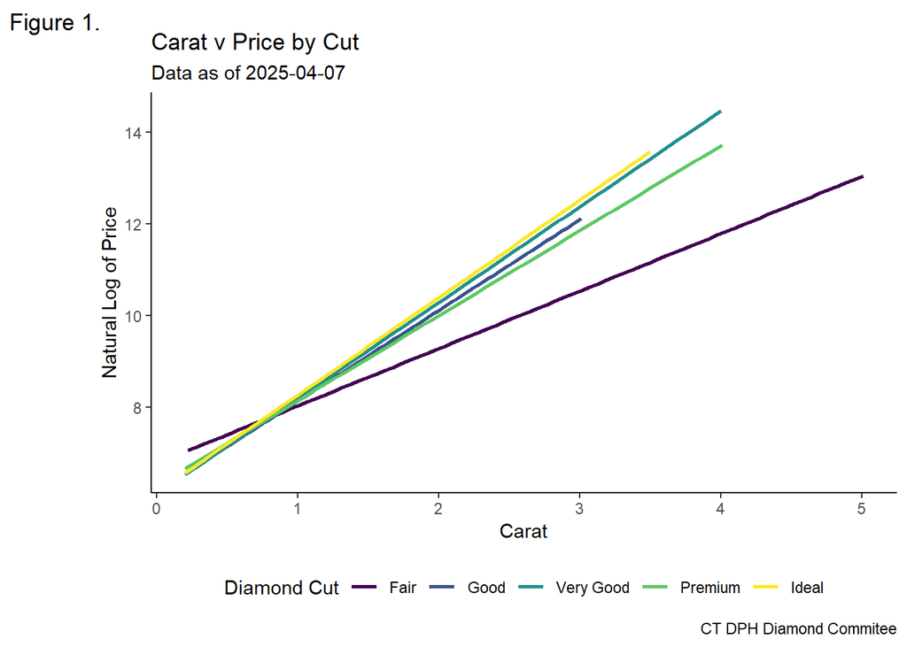

```r
with_labels +
  theme(
    legend.direction = "horizontal",
    legend.position = "bottom"
  )
```